# Risk Factor Analysis

## Outcome Variable

**Outcome Variable:** stunted

## Predictor Variables

**Intervention Variable:** mhtcm

**Adjustment Set:**

- arm
- W_mage
- meducyrs
- feducyrs
- hhwealth_quart
- single
- delta_W_mage
- delta_meducyrs
- delta_feducyrs
- delta_hhwealth_quart
- delta_single

## Stratifying Variables

The analysis was stratified on these variable(s):

- agecat
- studyid
- country

## Data Summary

| agecat | studyid | country | mhtcm | stunted | n_cell | n |
| --- | --- | --- | --- | --- | --- | --- |
| Birth | COHORTS | GUATEMALA | >=155 cm | 0 | 104 | 840 |
| Birth | COHORTS | GUATEMALA | >=155 cm | 1 | 6 | 840 |
| Birth | COHORTS | GUATEMALA | <151 cm | 0 | 513 | 840 |
| Birth | COHORTS | GUATEMALA | <151 cm | 1 | 32 | 840 |
| Birth | COHORTS | GUATEMALA | [151-155) cm | 0 | 174 | 840 |
| Birth | COHORTS | GUATEMALA | [151-155) cm | 1 | 11 | 840 |
| Birth | COHORTS | INDIA | >=155 cm | 0 | 497 | 1774 |
| Birth | COHORTS | INDIA | >=155 cm | 1 | 33 | 1774 |
| Birth | COHORTS | INDIA | <151 cm | 0 | 657 | 1774 |
| Birth | COHORTS | INDIA | <151 cm | 1 | 106 | 1774 |
| Birth | COHORTS | INDIA | [151-155) cm | 0 | 436 | 1774 |
| Birth | COHORTS | INDIA | [151-155) cm | 1 | 45 | 1774 |
| Birth | COHORTS | PHILIPPINES | >=155 cm | 0 | 614 | 3050 |
| Birth | COHORTS | PHILIPPINES | >=155 cm | 1 | 16 | 3050 |
| Birth | COHORTS | PHILIPPINES | <151 cm | 0 | 1413 | 3050 |
| Birth | COHORTS | PHILIPPINES | <151 cm | 1 | 132 | 3050 |
| Birth | COHORTS | PHILIPPINES | [151-155) cm | 0 | 836 | 3050 |
| Birth | COHORTS | PHILIPPINES | [151-155) cm | 1 | 39 | 3050 |
| Birth | JiVitA-3 | BANGLADESH | >=155 cm | 0 | 2670 | 22356 |
| Birth | JiVitA-3 | BANGLADESH | >=155 cm | 1 | 647 | 22356 |
| Birth | JiVitA-3 | BANGLADESH | <151 cm | 0 | 8258 | 22356 |
| Birth | JiVitA-3 | BANGLADESH | <151 cm | 1 | 5178 | 22356 |
| Birth | JiVitA-3 | BANGLADESH | [151-155) cm | 0 | 4076 | 22356 |
| Birth | JiVitA-3 | BANGLADESH | [151-155) cm | 1 | 1527 | 22356 |
| Birth | Keneba | GAMBIA | >=155 cm | 0 | 1130 | 1431 |
| Birth | Keneba | GAMBIA | >=155 cm | 1 | 57 | 1431 |
| Birth | Keneba | GAMBIA | <151 cm | 0 | 46 | 1431 |
| Birth | Keneba | GAMBIA | <151 cm | 1 | 5 | 1431 |
| Birth | Keneba | GAMBIA | [151-155) cm | 0 | 182 | 1431 |
| Birth | Keneba | GAMBIA | [151-155) cm | 1 | 11 | 1431 |

[output cut: 324 more lines]

The following strata were considered:

- agecat: 24 months, studyid: COHORTS, country: GUATEMALA
- agecat: 24 months, studyid: COHORTS, country: INDIA
- agecat: 24 months, studyid: COHORTS, country: PHILIPPINES
- agecat: 24 months, studyid: JiVitA-3, country: BANGLADESH
- agecat: 24 months, studyid: Keneba, country: GAMBIA
- agecat: 24 months, studyid: LCNI-5, country: MALAWI
- agecat: 24 months, studyid: MAL-ED, country: BANGLADESH
- agecat: 24 months, studyid: MAL-ED, country: BRAZIL
- agecat: 24 months, studyid: MAL-ED, country: INDIA
- agecat: 24 months, studyid: MAL-ED, country: NEPAL
- agecat: 24 months, studyid: MAL-ED, country: PERU
- agecat: 24 months, studyid: MAL-ED, country: SOUTH AFRICA
- agecat: 24 months, studyid: MAL-ED, country: TANZANIA, UNITED REPUBLIC OF
- agecat: 24 months, studyid: NIH-Birth, country: BANGLADESH
- agecat: 24 months, studyid: NIH-Crypto, country: BANGLADESH
- agecat: 24 months, studyid: PROBIT, country: BELARUS
- agecat: 24 months, studyid: PROVIDE, country: BANGLADESH
- agecat: 24 months, studyid: TanzaniaChild2, country: TANZANIA, UNITED REPUBLIC OF
- agecat: 24 months, studyid: ZVITAMBO, country: ZIMBABWE
- agecat: 6 months, studyid: COHORTS, country: GUATEMALA
- agecat: 6 months, studyid: COHORTS, country: INDIA
- agecat: 6 months, studyid: COHORTS, country: PHILIPPINES
- agecat: 6 months, studyid: Guatemala BSC, country: GUATEMALA
- agecat: 6 months, studyid: JiVitA-3, country: BANGLADESH
- agecat: 6 months, studyid: Keneba, country: GAMBIA
- agecat: 6 months, studyid: LCNI-5, country: MALAWI
- agecat: 6 months, studyid: MAL-ED, country: BANGLADESH
- agecat: 6 months, studyid: MAL-ED, country: BRAZIL
- agecat: 6 months, studyid: MAL-ED, country: INDIA
- agecat: 6 months, studyid: MAL-ED, country: NEPAL
- agecat: 6 months, studyid: MAL-ED, country: PERU
- agecat: 6 months, studyid: MAL-ED, country: SOUTH AFRICA
- agecat: 6 months, studyid: MAL-ED, country: TANZANIA, UNITED REPUBLIC OF
- agecat: 6 months, studyid: NIH-Birth, country: BANGLADESH
- agecat: 6 months, studyid: NIH-Crypto, country: BANGLADESH
- agecat: 6 months, studyid: PROBIT, country: BELARUS
- agecat: 6 months, studyid: PROVIDE, country: BANGLADESH
- agecat: 6 months, studyid: SAS-CompFeed, country: INDIA
- agecat: 6 months, studyid: SAS-FoodSuppl, country: INDIA
- agecat: 6 months, studyid: TanzaniaChild2, country: TANZANIA, UNITED REPUBLIC OF
- agecat: 6 months, studyid: ZVITAMBO, country: ZIMBABWE
- agecat: Birth, studyid: COHORTS, country: GUATEMALA
- agecat: Birth, studyid: COHORTS, country: INDIA
- agecat: Birth, studyid: COHORTS, country: PHILIPPINES
- agecat: Birth, studyid: JiVitA-3, country: BANGLADESH
- agecat: Birth, studyid: Keneba, country: GAMBIA
- agecat: Birth, studyid: MAL-ED, country: BANGLADESH
- agecat: Birth, studyid: MAL-ED, country: BRAZIL
- agecat: Birth, studyid: MAL-ED, country: INDIA
- agecat: Birth, studyid: MAL-ED, country: NEPAL
- agecat: Birth, studyid: MAL-ED, country: PERU
- agecat: Birth, studyid: MAL-ED, country: SOUTH AFRICA
- agecat: Birth, studyid: MAL-ED, country: TANZANIA, UNITED REPUBLIC OF
- agecat: Birth, studyid: NIH-Birth, country: BANGLADESH
- agecat: Birth, studyid: NIH-Crypto, country: BANGLADESH
- agecat: Birth, studyid: PROBIT, country: BELARUS
- agecat: Birth, studyid: PROVIDE, country: BANGLADESH
- agecat: Birth, studyid: SAS-CompFeed, country: INDIA
- agecat: Birth, studyid: ZVITAMBO, country: ZIMBABWE

### Dropped Strata

Some strata were dropped due to rare outcomes:

- agecat: Birth, studyid: MAL-ED, country: BANGLADESH
- agecat: Birth, studyid: MAL-ED, country: BRAZIL
- agecat: Birth, studyid: MAL-ED, country: INDIA
- agecat: Birth, studyid: MAL-ED, country: NEPAL
- agecat: Birth, studyid: MAL-ED, country: PERU
- agecat: Birth, studyid: MAL-ED, country: SOUTH AFRICA
- agecat: Birth, studyid: PROBIT, country: BELARUS
- agecat: 6 months, studyid: MAL-ED, country: BANGLADESH
- agecat: 6 months, studyid: MAL-ED, country: BRAZIL
- agecat: 6 months, studyid: MAL-ED, country: NEPAL
- agecat: 24 months, studyid: MAL-ED, country: BANGLADESH
- agecat: 24 months, studyid: MAL-ED, country: BRAZIL
- agecat: 24 months, studyid: MAL-ED, country: NEPAL
- agecat: 24 months, studyid: MAL-ED, country: TANZANIA, UNITED REPUBLIC OF
- agecat: 24 months, studyid: TanzaniaChild2, country: TANZANIA, UNITED REPUBLIC OF

## Methods Detail

We’re interested in the causal parameters $E[Y_a]$ for all values of $a \in \mathcal{A}$. These parameters represent the mean outcome if, possibly contrary to fact, we intervened to set all units to have $A=a$. Under the randomization and positivity assumptions, these are identified by the statistical parameters $\psi_a=E_W[E_{Y|A,W}(Y|A=a,W)]$. In addition, we’re interested in the mean of $Y$, $E[Y]$ under no intervention (the observed mean). We will estimate these parameters by using SuperLearner to fit the relevant likelihood factors – $E_{Y|A,W}(Y|A=a,W)$ and $p(A=a|W)$, and then updating our likelihood fit using a joint TMLE.

For unadjusted analyses ($W=\{\}$), initial likelihoods were estimated using Lrnr_glm to estimate the simple $E(Y|A)$ and Lrnr_mean to estimate $p(A)$. For adjusted analyses, a small library containing Lrnr_glmnet, Lrnr_xgboost, and Lrnr_mean was used.

Having estimated these parameters, we will then use the delta method to estimate relative risks and attributable risks relative to a prespecified baseline level of $A$.

# Results Detail

## Results Plots

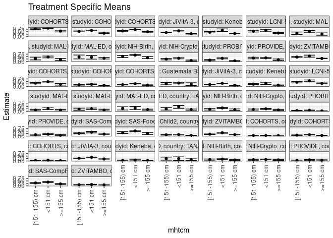

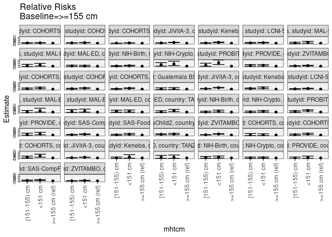

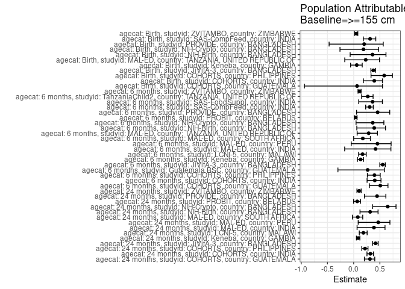

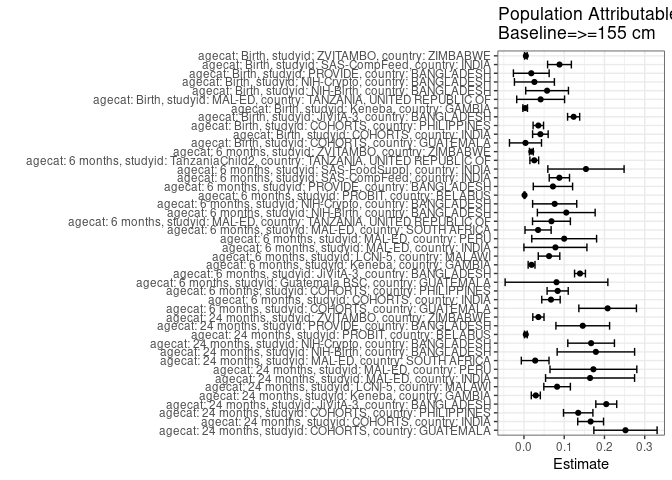

## Results Table

### Parameter: TSM

| agecat | studyid | country | intervention_level | baseline_level | estimate | ci_lower | ci_upper |
| --- | --- | --- | --- | --- | --- | --- | --- |
| Birth | COHORTS | GUATEMALA | >=155 cm | NA | 0.0545455 | 0.0120825 | 0.0970084 |
| Birth | COHORTS | GUATEMALA | <151 cm | NA | 0.0587156 | 0.0389666 | 0.0784646 |
| Birth | COHORTS | GUATEMALA | [151-155) cm | NA | 0.0594595 | 0.0253621 | 0.0935568 |
| Birth | COHORTS | INDIA | >=155 cm | NA | 0.0629373 | 0.0423357 | 0.0835389 |
| Birth | COHORTS | INDIA | <151 cm | NA | 0.1401211 | 0.1154447 | 0.1647975 |
| Birth | COHORTS | INDIA | [151-155) cm | NA | 0.0929864 | 0.0667583 | 0.1192144 |
| Birth | COHORTS | PHILIPPINES | >=155 cm | NA | 0.0256468 | 0.0130409 | 0.0382526 |
| Birth | COHORTS | PHILIPPINES | <151 cm | NA | 0.0829267 | 0.0692466 | 0.0966068 |
| Birth | COHORTS | PHILIPPINES | [151-155) cm | NA | 0.0462442 | 0.0320602 | 0.0604282 |
| Birth | JiVitA-3 | BANGLADESH | >=155 cm | NA | 0.2054899 | 0.1896770 | 0.2213027 |
| Birth | JiVitA-3 | BANGLADESH | <151 cm | NA | 0.3783676 | 0.3689568 | 0.3877784 |
| Birth | JiVitA-3 | BANGLADESH | [151-155) cm | NA | 0.2800047 | 0.2665164 | 0.2934930 |
| Birth | Keneba | GAMBIA | >=155 cm | NA | 0.0480202 | 0.0358527 | 0.0601877 |
| Birth | Keneba | GAMBIA | <151 cm | NA | 0.0980392 | 0.0163982 | 0.1796803 |
| Birth | Keneba | GAMBIA | [151-155) cm | NA | 0.0569948 | 0.0242761 | 0.0897135 |
| Birth | MAL-ED | TANZANIA, UNITED REPUBLIC OF | >=155 cm | NA | 0.1388889 | 0.0586782 | 0.2190996 |
| Birth | MAL-ED | TANZANIA, UNITED REPUBLIC OF | <151 cm | NA | 0.2380952 | 0.0551794 | 0.4210111 |
| Birth | MAL-ED | TANZANIA, UNITED REPUBLIC OF | [151-155) cm | NA | 0.2413793 | 0.0849930 | 0.3977656 |
| Birth | NIH-Birth | BANGLADESH | >=155 cm | NA | 0.1021183 | 0.0464586 | 0.1577781 |
| Birth | NIH-Birth | BANGLADESH | <151 cm | NA | 0.1899405 | 0.1492734 | 0.2306076 |
| Birth | NIH-Birth | BANGLADESH | [151-155) cm | NA | 0.1465140 | 0.0895250 | 0.2035029 |
| Birth | NIH-Crypto | BANGLADESH | >=155 cm | NA | 0.1125903 | 0.0588516 | 0.1663289 |
| Birth | NIH-Crypto | BANGLADESH | <151 cm | NA | 0.1497944 | 0.1153830 | 0.1842058 |
| Birth | NIH-Crypto | BANGLADESH | [151-155) cm | NA | 0.1285078 | 0.0787938 | 0.1782219 |
| Birth | PROVIDE | BANGLADESH | >=155 cm | NA | 0.0727273 | 0.0241510 | 0.1213036 |
| Birth | PROVIDE | BANGLADESH | <151 cm | NA | 0.1118881 | 0.0753193 | 0.1484570 |
| Birth | PROVIDE | BANGLADESH | [151-155) cm | NA | 0.0578512 | 0.0162130 | 0.0994894 |
| Birth | SAS-CompFeed | INDIA | >=155 cm | NA | 0.1937209 | 0.1450186 | 0.2424232 |
| Birth | SAS-CompFeed | INDIA | <151 cm | NA | 0.3799385 | 0.3307206 | 0.4291565 |
| Birth | SAS-CompFeed | INDIA | [151-155) cm | NA | 0.2929121 | 0.2382778 | 0.3475464 |

[output cut: 102 more lines]

### Parameter: E(Y)

| agecat | studyid | country | intervention_level | baseline_level | estimate | ci_lower | ci_upper |
| --- | --- | --- | --- | --- | --- | --- | --- |
| Birth | COHORTS | GUATEMALA | NA | NA | 0.0583333 | 0.0424744 | 0.0741923 |
| Birth | COHORTS | INDIA | NA | NA | 0.1037204 | 0.0895283 | 0.1179125 |
| Birth | COHORTS | PHILIPPINES | NA | NA | 0.0613115 | 0.0527962 | 0.0698268 |
| Birth | JiVitA-3 | BANGLADESH | NA | NA | 0.3288603 | 0.3214821 | 0.3362385 |
| Birth | Keneba | GAMBIA | NA | NA | 0.0510133 | 0.0396094 | 0.0624171 |
| Birth | MAL-ED | TANZANIA, UNITED REPUBLIC OF | NA | NA | 0.1803279 | 0.1118253 | 0.2488304 |
| Birth | NIH-Birth | BANGLADESH | NA | NA | 0.1595395 | 0.1304091 | 0.1886699 |
| Birth | NIH-Crypto | BANGLADESH | NA | NA | 0.1385460 | 0.1134505 | 0.1636414 |
| Birth | PROVIDE | BANGLADESH | NA | NA | 0.0909091 | 0.0661046 | 0.1157136 |
| Birth | SAS-CompFeed | INDIA | NA | NA | 0.2819383 | 0.2495848 | 0.3142918 |
| Birth | ZVITAMBO | ZIMBABWE | NA | NA | 0.0988150 | 0.0928777 | 0.1047524 |
| 6 months | COHORTS | GUATEMALA | NA | NA | 0.4093319 | 0.3779317 | 0.4407321 |
| 6 months | COHORTS | INDIA | NA | NA | 0.1665750 | 0.1494477 | 0.1837024 |
| 6 months | COHORTS | PHILIPPINES | NA | NA | 0.2112260 | 0.1958496 | 0.2266024 |
| 6 months | Guatemala BSC | GUATEMALA | NA | NA | 0.3030303 | 0.2436375 | 0.3624232 |
| 6 months | JiVitA-3 | BANGLADESH | NA | NA | 0.2515363 | 0.2434210 | 0.2596516 |
| 6 months | Keneba | GAMBIA | NA | NA | 0.1427810 | 0.1269499 | 0.1586122 |
| 6 months | LCNI-5 | MALAWI | NA | NA | 0.3672249 | 0.3345288 | 0.3999210 |
| 6 months | MAL-ED | INDIA | NA | NA | 0.1872340 | 0.1372518 | 0.2372162 |
| 6 months | MAL-ED | PERU | NA | NA | 0.2205882 | 0.1712211 | 0.2699554 |
| 6 months | MAL-ED | SOUTH AFRICA | NA | NA | 0.2008032 | 0.1509453 | 0.2506612 |
| 6 months | MAL-ED | TANZANIA, UNITED REPUBLIC OF | NA | NA | 0.2388664 | 0.1855834 | 0.2921494 |
| 6 months | NIH-Birth | BANGLADESH | NA | NA | 0.2681564 | 0.2306532 | 0.3056597 |
| 6 months | NIH-Crypto | BANGLADESH | NA | NA | 0.2097902 | 0.1799252 | 0.2396552 |
| 6 months | PROBIT | BELARUS | NA | NA | 0.0368352 | 0.0276810 | 0.0459895 |
| 6 months | PROVIDE | BANGLADESH | NA | NA | 0.1575456 | 0.1284434 | 0.1866478 |
| 6 months | SAS-CompFeed | INDIA | NA | NA | 0.2882736 | 0.2624662 | 0.3140810 |
| 6 months | SAS-FoodSuppl | INDIA | NA | NA | 0.4274406 | 0.3775694 | 0.4773119 |
| 6 months | TanzaniaChild2 | TANZANIA, UNITED REPUBLIC OF | NA | NA | 0.0951904 | 0.0823123 | 0.1080685 |
| 6 months | ZVITAMBO | ZIMBABWE | NA | NA | 0.1632405 | 0.1548158 | 0.1716651 |
| 24 months | COHORTS | GUATEMALA | NA | NA | 0.8128773 | 0.7886196 | 0.8371349 |
| 24 months | COHORTS | INDIA | NA | NA | 0.5195162 | 0.4965500 | 0.5424825 |
| 24 months | COHORTS | PHILIPPINES | NA | NA | 0.6229039 | 0.6036892 | 0.6421186 |
| 24 months | JiVitA-3 | BANGLADESH | NA | NA | 0.4914525 | 0.4783104 | 0.5045946 |
| 24 months | Keneba | GAMBIA | NA | NA | 0.3420724 | 0.3188343 | 0.3653105 |
| 24 months | LCNI-5 | MALAWI | NA | NA | 0.4436742 | 0.4031015 | 0.4842468 |
| 24 months | MAL-ED | INDIA | NA | NA | 0.4247788 | 0.3601902 | 0.4893673 |
| 24 months | MAL-ED | PERU | NA | NA | 0.3681592 | 0.3013164 | 0.4350020 |
| 24 months | MAL-ED | SOUTH AFRICA | NA | NA | 0.3504274 | 0.2891665 | 0.4116882 |
| 24 months | NIH-Birth | BANGLADESH | NA | NA | 0.5687646 | 0.5218455 | 0.6156837 |
| 24 months | NIH-Crypto | BANGLADESH | NA | NA | 0.2568093 | 0.2190047 | 0.2946140 |
| 24 months | PROBIT | BELARUS | NA | NA | 0.0679151 | 0.0407521 | 0.0950781 |
| 24 months | PROVIDE | BANGLADESH | NA | NA | 0.3275563 | 0.2892291 | 0.3658836 |
| 24 months | ZVITAMBO | ZIMBABWE | NA | NA | 0.3464338 | 0.3212647 | 0.3716029 |

### Parameter: RR

| agecat | studyid | country | intervention_level | baseline_level | estimate | ci_lower | ci_upper |
| --- | --- | --- | --- | --- | --- | --- | --- |
| Birth | COHORTS | GUATEMALA | >=155 cm | >=155 cm | 1.0000000 | 1.0000000 | 1.000000 |
| Birth | COHORTS | GUATEMALA | <151 cm | >=155 cm | 1.0764526 | 0.4609940 | 2.513591 |
| Birth | COHORTS | GUATEMALA | [151-155) cm | >=155 cm | 1.0900901 | 0.4145183 | 2.866692 |
| Birth | COHORTS | INDIA | >=155 cm | >=155 cm | 1.0000000 | 1.0000000 | 1.000000 |
| Birth | COHORTS | INDIA | <151 cm | >=155 cm | 2.2263611 | 1.5349237 | 3.229270 |
| Birth | COHORTS | INDIA | [151-155) cm | >=155 cm | 1.4774447 | 0.9591377 | 2.275839 |
| Birth | COHORTS | PHILIPPINES | >=155 cm | >=155 cm | 1.0000000 | 1.0000000 | 1.000000 |
| Birth | COHORTS | PHILIPPINES | <151 cm | >=155 cm | 3.2334162 | 1.9254207 | 5.429972 |
| Birth | COHORTS | PHILIPPINES | [151-155) cm | >=155 cm | 1.8031214 | 1.0103239 | 3.218024 |
| Birth | JiVitA-3 | BANGLADESH | >=155 cm | >=155 cm | 1.0000000 | 1.0000000 | 1.000000 |
| Birth | JiVitA-3 | BANGLADESH | <151 cm | >=155 cm | 1.8412955 | 1.6999432 | 1.994401 |
| Birth | JiVitA-3 | BANGLADESH | [151-155) cm | >=155 cm | 1.3626204 | 1.2453187 | 1.490971 |
| Birth | Keneba | GAMBIA | >=155 cm | >=155 cm | 1.0000000 | 1.0000000 | 1.000000 |
| Birth | Keneba | GAMBIA | <151 cm | >=155 cm | 2.0416237 | 0.8549698 | 4.875292 |
| Birth | Keneba | GAMBIA | [151-155) cm | >=155 cm | 1.1868921 | 0.6337132 | 2.222950 |
| Birth | MAL-ED | TANZANIA, UNITED REPUBLIC OF | >=155 cm | >=155 cm | 1.0000000 | 1.0000000 | 1.000000 |
| Birth | MAL-ED | TANZANIA, UNITED REPUBLIC OF | <151 cm | >=155 cm | 1.7142857 | 0.6556608 | 4.482158 |
| Birth | MAL-ED | TANZANIA, UNITED REPUBLIC OF | [151-155) cm | >=155 cm | 1.7379310 | 0.7296261 | 4.139661 |
| Birth | NIH-Birth | BANGLADESH | >=155 cm | >=155 cm | 1.0000000 | 1.0000000 | 1.000000 |
| Birth | NIH-Birth | BANGLADESH | <151 cm | >=155 cm | 1.8600040 | 1.0351134 | 3.342257 |
| Birth | NIH-Birth | BANGLADESH | [151-155) cm | >=155 cm | 1.4347470 | 0.7349338 | 2.800931 |
| Birth | NIH-Crypto | BANGLADESH | >=155 cm | >=155 cm | 1.0000000 | 1.0000000 | 1.000000 |
| Birth | NIH-Crypto | BANGLADESH | <151 cm | >=155 cm | 1.3304380 | 0.7830940 | 2.260348 |
| Birth | NIH-Crypto | BANGLADESH | [151-155) cm | >=155 cm | 1.1413758 | 0.6177451 | 2.108861 |
| Birth | PROVIDE | BANGLADESH | >=155 cm | >=155 cm | 1.0000000 | 1.0000000 | 1.000000 |
| Birth | PROVIDE | BANGLADESH | <151 cm | >=155 cm | 1.5384615 | 0.7313825 | 3.236151 |
| Birth | PROVIDE | BANGLADESH | [151-155) cm | >=155 cm | 0.7954545 | 0.2979717 | 2.123517 |
| Birth | SAS-CompFeed | INDIA | >=155 cm | >=155 cm | 1.0000000 | 1.0000000 | 1.000000 |
| Birth | SAS-CompFeed | INDIA | <151 cm | >=155 cm | 1.9612675 | 1.5116369 | 2.544639 |
| Birth | SAS-CompFeed | INDIA | [151-155) cm | >=155 cm | 1.5120314 | 1.0796786 | 2.117518 |

[output cut: 102 more lines]

### Parameter: PAR

| agecat | studyid | country | intervention_level | baseline_level | estimate | ci_lower | ci_upper |
| --- | --- | --- | --- | --- | --- | --- | --- |
| Birth | COHORTS | GUATEMALA | >=155 cm | NA | 0.0037879 | -0.0359911 | 0.0435668 |
| Birth | COHORTS | INDIA | >=155 cm | NA | 0.0407831 | 0.0214637 | 0.0601026 |
| Birth | COHORTS | PHILIPPINES | >=155 cm | NA | 0.0356647 | 0.0226788 | 0.0486506 |
| Birth | JiVitA-3 | BANGLADESH | >=155 cm | NA | 0.1233704 | 0.1083607 | 0.1383801 |
| Birth | Keneba | GAMBIA | >=155 cm | NA | 0.0029931 | -0.0027067 | 0.0086929 |
| Birth | MAL-ED | TANZANIA, UNITED REPUBLIC OF | >=155 cm | NA | 0.0414390 | -0.0179952 | 0.1008731 |
| Birth | NIH-Birth | BANGLADESH | >=155 cm | NA | 0.0574211 | 0.0043460 | 0.1104962 |
| Birth | NIH-Crypto | BANGLADESH | >=155 cm | NA | 0.0259557 | -0.0236776 | 0.0755889 |
| Birth | PROVIDE | BANGLADESH | >=155 cm | NA | 0.0181818 | -0.0262120 | 0.0625756 |
| Birth | SAS-CompFeed | INDIA | >=155 cm | NA | 0.0882174 | 0.0586814 | 0.1177535 |
| Birth | ZVITAMBO | ZIMBABWE | >=155 cm | NA | 0.0047008 | 0.0015139 | 0.0078877 |
| 6 months | COHORTS | GUATEMALA | >=155 cm | NA | 0.2078661 | 0.1363459 | 0.2793862 |
| 6 months | COHORTS | INDIA | >=155 cm | NA | 0.0670778 | 0.0442059 | 0.0899497 |
| 6 months | COHORTS | PHILIPPINES | >=155 cm | NA | 0.0836956 | 0.0574560 | 0.1099351 |
| 6 months | Guatemala BSC | GUATEMALA | >=155 cm | NA | 0.0808081 | -0.0467748 | 0.2083909 |
| 6 months | JiVitA-3 | BANGLADESH | >=155 cm | NA | 0.1391921 | 0.1256776 | 0.1527067 |
| 6 months | Keneba | GAMBIA | >=155 cm | NA | 0.0188953 | 0.0103811 | 0.0274095 |
| 6 months | LCNI-5 | MALAWI | >=155 cm | NA | 0.0622999 | 0.0355555 | 0.0890444 |
| 6 months | MAL-ED | INDIA | >=155 cm | NA | 0.0781431 | -0.0001154 | 0.1564017 |
| 6 months | MAL-ED | PERU | >=155 cm | NA | 0.0998986 | 0.0193802 | 0.1804169 |
| 6 months | MAL-ED | SOUTH AFRICA | >=155 cm | NA | 0.0350278 | 0.0025639 | 0.0674917 |
| 6 months | MAL-ED | TANZANIA, UNITED REPUBLIC OF | >=155 cm | NA | 0.0682926 | 0.0212887 | 0.1152966 |
| 6 months | NIH-Birth | BANGLADESH | >=155 cm | NA | 0.1050563 | 0.0333145 | 0.1767982 |
| 6 months | NIH-Crypto | BANGLADESH | >=155 cm | NA | 0.0762804 | 0.0214752 | 0.1310855 |
| 6 months | PROBIT | BELARUS | >=155 cm | NA | 0.0014381 | 0.0003677 | 0.0025084 |
| 6 months | PROVIDE | BANGLADESH | >=155 cm | NA | 0.0719716 | 0.0231415 | 0.1208017 |
| 6 months | SAS-CompFeed | INDIA | >=155 cm | NA | 0.0879348 | 0.0627320 | 0.1131377 |
| 6 months | SAS-FoodSuppl | INDIA | >=155 cm | NA | 0.1540109 | 0.0592968 | 0.2487249 |
| 6 months | TanzaniaChild2 | TANZANIA, UNITED REPUBLIC OF | >=155 cm | NA | 0.0256087 | 0.0147451 | 0.0364724 |
| 6 months | ZVITAMBO | ZIMBABWE | >=155 cm | NA | 0.0183828 | 0.0135714 | 0.0231941 |
| 24 months | COHORTS | GUATEMALA | >=155 cm | NA | 0.2521616 | 0.1736180 | 0.3307052 |
| 24 months | COHORTS | INDIA | >=155 cm | NA | 0.1656078 | 0.1335605 | 0.1976551 |
| 24 months | COHORTS | PHILIPPINES | >=155 cm | NA | 0.1347467 | 0.0982325 | 0.1712609 |
| 24 months | JiVitA-3 | BANGLADESH | >=155 cm | NA | 0.2044639 | 0.1785125 | 0.2304152 |
| 24 months | Keneba | GAMBIA | >=155 cm | NA | 0.0294111 | 0.0181852 | 0.0406370 |
| 24 months | LCNI-5 | MALAWI | >=155 cm | NA | 0.0823116 | 0.0493458 | 0.1152774 |
| 24 months | MAL-ED | INDIA | >=155 cm | NA | 0.1642135 | 0.0536645 | 0.2747624 |
| 24 months | MAL-ED | PERU | >=155 cm | NA | 0.1725070 | 0.0646625 | 0.2803516 |
| 24 months | MAL-ED | SOUTH AFRICA | >=155 cm | NA | 0.0278248 | -0.0065745 | 0.0622240 |
| 24 months | NIH-Birth | BANGLADESH | >=155 cm | NA | 0.1786335 | 0.0824293 | 0.2748376 |
| 24 months | NIH-Crypto | BANGLADESH | >=155 cm | NA | 0.1668093 | 0.1088878 | 0.2247309 |
| 24 months | PROBIT | BELARUS | >=155 cm | NA | 0.0046110 | 0.0011781 | 0.0080440 |
| 24 months | PROVIDE | BANGLADESH | >=155 cm | NA | 0.1460378 | 0.0793892 | 0.2126864 |
| 24 months | ZVITAMBO | ZIMBABWE | >=155 cm | NA | 0.0358693 | 0.0219468 | 0.0497917 |

### Parameter: PAF

| agecat | studyid | country | intervention_level | baseline_level | estimate | ci_lower | ci_upper |
| --- | --- | --- | --- | --- | --- | --- | --- |
| Birth | COHORTS | GUATEMALA | >=155 cm | NA | 0.0649351 | -0.9385216 | 0.5489623 |
| Birth | COHORTS | INDIA | >=155 cm | NA | 0.3932025 | 0.1847867 | 0.5483352 |
| Birth | COHORTS | PHILIPPINES | >=155 cm | NA | 0.5816971 | 0.3306811 | 0.7385741 |
| Birth | JiVitA-3 | BANGLADESH | >=155 cm | NA | 0.3751453 | 0.3281754 | 0.4188314 |
| Birth | Keneba | GAMBIA | >=155 cm | NA | 0.0586721 | -0.0591796 | 0.1634109 |
| Birth | MAL-ED | TANZANIA, UNITED REPUBLIC OF | >=155 cm | NA | 0.2297980 | -0.1697411 | 0.4928697 |
| Birth | NIH-Birth | BANGLADESH | >=155 cm | NA | 0.3599180 | -0.0669509 | 0.6160039 |
| Birth | NIH-Crypto | BANGLADESH | >=155 cm | NA | 0.1873434 | -0.2610145 | 0.4762861 |
| Birth | PROVIDE | BANGLADESH | >=155 cm | NA | 0.2000000 | -0.4682360 | 0.5641028 |
| Birth | SAS-CompFeed | INDIA | >=155 cm | NA | 0.3128961 | 0.1835434 | 0.4217553 |
| Birth | ZVITAMBO | ZIMBABWE | >=155 cm | NA | 0.0475719 | 0.0148746 | 0.0791839 |
| 6 months | COHORTS | GUATEMALA | >=155 cm | NA | 0.5078179 | 0.2996985 | 0.6540872 |
| 6 months | COHORTS | INDIA | >=155 cm | NA | 0.4026882 | 0.2557861 | 0.5205929 |
| 6 months | COHORTS | PHILIPPINES | >=155 cm | NA | 0.3962370 | 0.2614496 | 0.5064253 |
| 6 months | Guatemala BSC | GUATEMALA | >=155 cm | NA | 0.2666667 | -0.2999982 | 0.5863242 |
| 6 months | JiVitA-3 | BANGLADESH | >=155 cm | NA | 0.5533680 | 0.4982886 | 0.6024007 |
| 6 months | Keneba | GAMBIA | >=155 cm | NA | 0.1323375 | 0.0720930 | 0.1886707 |
| 6 months | LCNI-5 | MALAWI | >=155 cm | NA | 0.1696506 | 0.0937077 | 0.2392299 |
| 6 months | MAL-ED | INDIA | >=155 cm | NA | 0.4173554 | -0.1715170 | 0.7102263 |
| 6 months | MAL-ED | PERU | >=155 cm | NA | 0.4528736 | -0.0471592 | 0.7141339 |
| 6 months | MAL-ED | SOUTH AFRICA | >=155 cm | NA | 0.1744385 | 0.0000171 | 0.3184365 |
| 6 months | MAL-ED | TANZANIA, UNITED REPUBLIC OF | >=155 cm | NA | 0.2859031 | 0.0662726 | 0.4538723 |
| 6 months | NIH-Birth | BANGLADESH | >=155 cm | NA | 0.3917726 | 0.0596572 | 0.6065897 |
| 6 months | NIH-Crypto | BANGLADESH | >=155 cm | NA | 0.3636031 | 0.0455177 | 0.5756851 |
| 6 months | PROBIT | BELARUS | >=155 cm | NA | 0.0390412 | 0.0125697 | 0.0648031 |
| 6 months | PROVIDE | BANGLADESH | >=155 cm | NA | 0.4568302 | 0.0548414 | 0.6878477 |
| 6 months | SAS-CompFeed | INDIA | >=155 cm | NA | 0.3050395 | 0.2284373 | 0.3740364 |
| 6 months | SAS-FoodSuppl | INDIA | >=155 cm | NA | 0.3603094 | 0.0957441 | 0.5474687 |
| 6 months | TanzaniaChild2 | TANZANIA, UNITED REPUBLIC OF | >=155 cm | NA | 0.2690262 | 0.1514930 | 0.3702789 |
| 6 months | ZVITAMBO | ZIMBABWE | >=155 cm | NA | 0.1126116 | 0.0830471 | 0.1412229 |
| 24 months | COHORTS | GUATEMALA | >=155 cm | NA | 0.3102087 | 0.2041869 | 0.4021057 |
| 24 months | COHORTS | INDIA | >=155 cm | NA | 0.3187731 | 0.2536876 | 0.3781825 |
| 24 months | COHORTS | PHILIPPINES | >=155 cm | NA | 0.2163202 | 0.1548610 | 0.2733100 |
| 24 months | JiVitA-3 | BANGLADESH | >=155 cm | NA | 0.4160400 | 0.3602308 | 0.4669807 |
| 24 months | Keneba | GAMBIA | >=155 cm | NA | 0.0859791 | 0.0525888 | 0.1181927 |
| 24 months | LCNI-5 | MALAWI | >=155 cm | NA | 0.1855226 | 0.1070908 | 0.2570652 |
| 24 months | MAL-ED | INDIA | >=155 cm | NA | 0.3865859 | 0.0650187 | 0.5975568 |
| 24 months | MAL-ED | PERU | >=155 cm | NA | 0.4685664 | 0.0859712 | 0.6910145 |
| 24 months | MAL-ED | SOUTH AFRICA | >=155 cm | NA | 0.0794024 | -0.0243120 | 0.1726154 |
| 24 months | NIH-Birth | BANGLADESH | >=155 cm | NA | 0.3140728 | 0.1207266 | 0.4649034 |
| 24 months | NIH-Crypto | BANGLADESH | >=155 cm | NA | 0.6495455 | 0.3626160 | 0.8073086 |
| 24 months | PROBIT | BELARUS | >=155 cm | NA | 0.0678938 | -0.0010735 | 0.1321097 |
| 24 months | PROVIDE | BANGLADESH | >=155 cm | NA | 0.4458403 | 0.2046907 | 0.6138698 |
| 24 months | ZVITAMBO | ZIMBABWE | >=155 cm | NA | 0.1035386 | 0.0624897 | 0.1427902 |